# Version control from RStudio

Git and GitHub using R

### Who are you?

- Lucy work with R and R studio to analyze data
- Lucy use R-Projects
- Lucy use RMarkdown to organize and document your work
- Lucy have tried different ways of sharing your work.
- She had heard about Git, and has the feeling that it might help. But she is not sure where to start.
- She wants to understand how Git and GitHub works and wants to integrate this with RStudio.

### Version control, what is that?

**Git:**

- saves all the changes that were done on the code,
- allows to access the history of changes and to go back to older versions of the code,
- allows to compare changes between different versions,
- helps with teamwork. Tracks who did each change,
- recover files that were deleted.

### Configure Git on RStudio

[figure not shown]

### Today

- Working locally
- Working remotely
- Working on a team (one possibility)
- Publishing MarkDown files on GitHub

### Working Locally

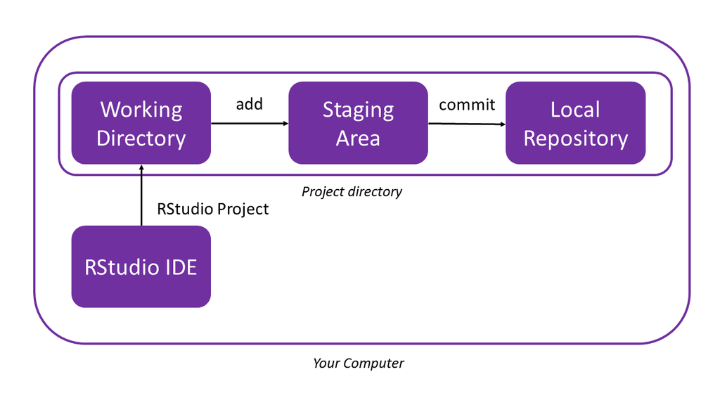

### Working Locally: Basic commands

*git add*

- **Description:** Adds file to staging area.
  - Prepares the content staged for the next commit.
  - Starts saving versions and changes of the file.
- **Options:**
  - git add file-path
  - git add -all

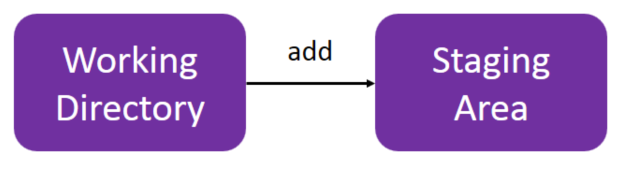

*git commit*

- **Description:** Saves changes into local repository-
  - Saves a version of the file.
  - Sends from staging area to local repositoriy.
  - Good practice: Only one/few tasks per commit.
  - Good practice: Write meaninfull commit messages.
- **Options:**
  - git commit -m “First commit”

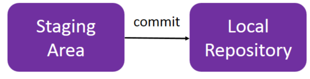

### Short Demo 1

### Short Demo 1

[figure not shown]

### Short Demo 1

[figure not shown]

### Short Demo 1

[figure not shown]

### Working remotely

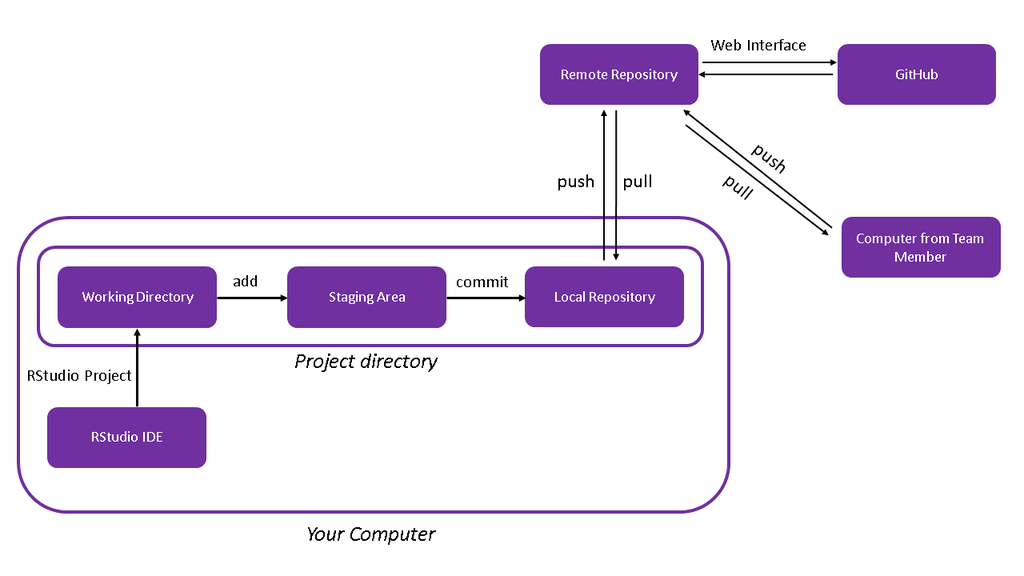

### Working remotely: Basic commands

*git pull*

- **Description:** Updates local repository from remote repository
  - Downloada changes from the remote repository to local repository.
  - A warning will appear if there is a conflict.
- **Options:**
  - git pull *remote*

[figure not shown]

*git push*

- **Description:** Send changes from local repository to remote repository.
  - A warning will appear if I do not have the latest version of the repository.
  - To avoid this, pull before pushing.
  - A warning will appear if there is there an incompatibility.
- **Options:**
  - git push

[figure not shown]

### Short Demo 2

### Short Demo 2

[figure not shown]

### Short Demo 2

[figure not shown]

### Short Demo 2

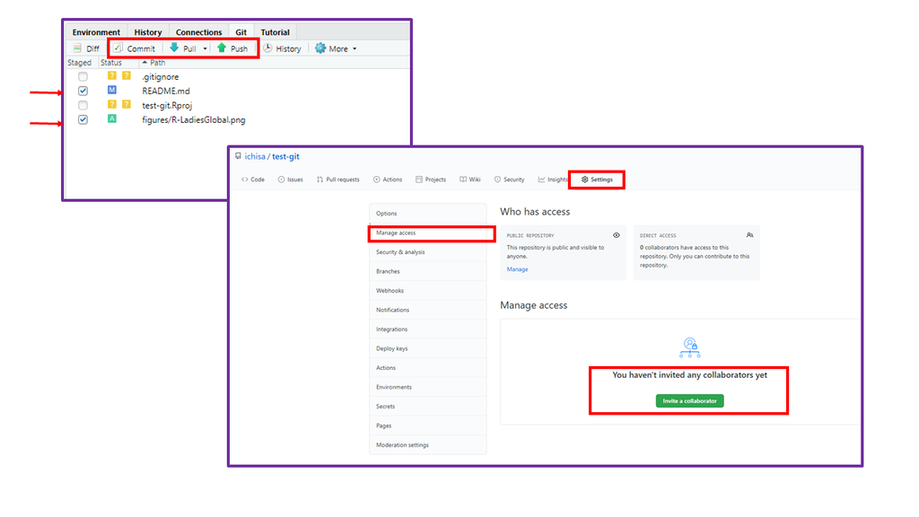

### File status life cycle

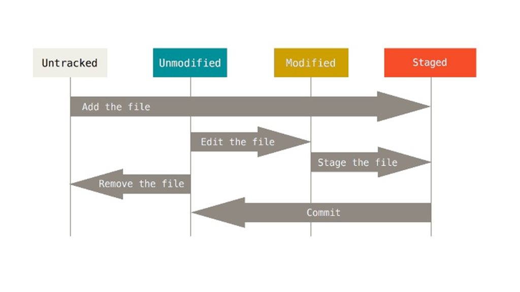

### Software we are using

[figure not shown]

### Short Demo 3

### Resources

## More about git using R

https://happygitwithr.com/

## Lern other possibilities to work with GIT

Introduction to Git and Github by Google on coursera

## Websites with GitHub

https://pages.github.com/

## Other resources used (in Spanish)

https://www.youtube.com/watch?v=33pZ9dtc-Co

https://github.com/rladies/meetup-presentations_buenosaires/blob/master/2019-09-14-Git_Rstudio/git_rstudio.pdf